# TERRE GRS: Prediction of case-control status

The manuscript “A Parkinson’s disease genetic risk score associates with blood DNAm on chromosome 17” explores how a genetic risk score (GRS) for Parkinson’s disease (PD) associates with blood DNA methylation in the TERRE study of French agricultural workers, and evaluates GRS associations with DNAm in each sex as well as their sensitivity to non-genetic factors. This was originally spearheaded by Will Casazza and was posted as a pre-print on medRxiv in 2023. The current revision (2024, led by Sam Schaffner) aims to address previous reviewer feedback and prepare the manuscript for re-submission.

This script evaluates how well the GRS can predict case-control status, in a cross-sex sample and sex-stratified samples. The 2024 update includes adjustment to the models where the 10 DNAm PCs are replaced with batch (plate and row, chip excluded for association with sex) and robust PCs of DNAm-predicted cell type proportions.

Last updated May 17, 2025 by Samantha Schaffner: check GRS was scaled, pull stats without the additional DNAm-related covariates, change liability scale calculation to represent Lee et al., Am J Hum Genet 2011.

Based on code by Will Casazza

# PD risk score data and matching

### Loading in and preparing data

This code reads in the Nalls 2019 PD risk score loci and organizes it into a table with alleles and weights for each SNP. Here, I matched the meta data with the CMR project meta data that includes cell type PCs and batch information.

```r
risk_scores <- read.delim("~/SHARE_DECIPHER/pd_grs_ewas_integration/prs_analyses/pd_prs_file.txt", header=FALSE, sep=" ")
head(risk_scores)
#           V1 V2      V3
#1 rs114138760  C  0.2812
#2  rs35749011  A  0.6068
#3  rs76763715  T -0.7467
#4   rs6658353  C  0.0650
#5  rs11578699  T -0.0704
#6    rs823118  T  0.1066

terre_prs <- fread("~/SHARE_DECIPHER/pd_grs_ewas_integration/prs_analyses/terre_prs.sscore")
# WC: this is the GRS generated with pT = 5e-8

terre_pcs <- fread("~/SHARE_DECIPHER/pd_grs_ewas_integration/TERRE_QC/raw_data.geno.maf.mind.sex_check.het_filter.ibd_filter.eigenvec")
#Columns V1 and V2 are ID labels, V3-V22 are PCs
terre_metadata <- read.csv("/home1/NEURO/SHARE_DECIPHER/terre_meta_master.csv") %>%
  mutate(
    FID = gsub("(PAE_[0-9]*_[1-9]*)_.*", "\\1", FID),
    IID = gsub("(PAE_[0-9]*_[1-9]*)_.*", "\\1", IID)
  )

all_data <- terre_prs %>%
  left_join(terre_metadata, by = c("IID")) %>%
  left_join(terre_pcs, by = c("IID" = "V1"))

# get genotype and DNAm PCs from the following file:
prsice_cov <- fread("~/SHARE_DECIPHER/pd_grs_ewas_integration/prs_analyses/prsice_cov_and_status_mvalues.txt")
all(prsice_cov$patient %in% all_data$patient) #TRUE
colnames(all_data) <- gsub("men", "sex", colnames(all_data))
meta <- left_join(prsice_cov, all_data, by=c("patient","PD","IID","sex","age","V3","V4","V5"))
colnames(meta) #rename DNAm and geno PC columns for clarity
colnames(meta)[1:10] <- paste("DNAm", colnames(meta)[1:10], sep="_")
colnames(meta)[13:15] <- paste("geno", colnames(meta)[13:15], sep="_")
meta <- meta[,-23] #remove extra dummy column "X"
colnames(meta)

# add batch and cell type variables
propensity_meta_F <- read.csv("~/SHARE_DECIPHER/processed_DNAm_data/2022/TERRE_processed_2022/3-terre_meta_F_probit_matched_4.5.3.csv")
propensity_meta_M <- read.csv("~/SHARE_DECIPHER/processed_DNAm_data/2022/TERRE_processed_2022/3-terre_meta_M_probit_matched_4.5.3.csv")
# fix sex columns
propensity_meta_F$reportedSex <- "F"
propensity_meta_M$reportedSex <- "M"
propensity_meta <- rbind(propensity_meta_F, propensity_meta_M)

# re-code and join
colnames(propensity_meta)[7] <- "sex"
meta$sex <- gsub(0, "F", gsub(1, "M", meta$sex))
all(propensity_meta$patient %in% meta$patient) #TRUE
cols <- colnames(meta)[colnames(meta) %in% colnames(propensity_meta)]
meta <- left_join(meta, propensity_meta, by=cols)
colnames(meta)
write.csv(meta, file="~/PD_GRS/meta_geno_DNAm_PCs.csv", row.names=F)

# DNAm data
load("~/SHARE_DECIPHER/processed_DNAm_data/2022/TERRE_processed_2022/1-TERRE_RG_filtered.RData")
mvals <- getM(PD_RG_filtered)
```

# Testing how well GRS explains case-control status

Prior to EWAS, testing GRS performance here in TERRE (cross-sex and sex-stratified). Models updated here May 17, 2025 to remove additional DNAm-related covariates not neccessary for inclusion in the models.

GRS performance is assessed here by comparing models predicting case-control status that include or do not include the GRS. The nagelkerke() function from the “rcompanion” package produces pseudo R-squared measurements, which indicate how well each model explains the data relative to each other. A higher R squared indicates better prediction of the outcome. The Nagelkerke measure is an more interpretable adjustment of the Cox and Snell measure, where the upper bound is 1.

Liability scale heritability for the PD GRS is also calculated, which assumes there is a continuous distribution of risk for PD that is influenced by genetic and environmental factors. Heritability is interpreted here as the proportion of variance in PD risk that is due to genetics.

### Scale GRS

The GRS should have a mean of 0 and SD of 1 after scaling.

```r
# check scaling of PGS: should have mean of 0, SD of 1
mean(meta$SCORE1_AVG) #-0.001894811
sd(meta$SCORE1_AVG) #0.003983904
plot(density(meta$SCORE1_AVG))

meta$GRS_scaled <- scale(meta$SCORE1_AVG)
mean(meta$GRS_scaled) #2.10256e-17
sd(meta$GRS_scaled) #1
par(mfrow=c(2,1))
plot(density(meta$SCORE1_AVG), main="GRS prior to scaling", xlim=c(-3,3))
plot(density(meta$GRS_scaled), main="GRS after scaling", xlim=c(-3,3))

write.csv(meta, file="~/PD_GRS/meta_geno_DNAm_PCs.csv", row.names=F)
```

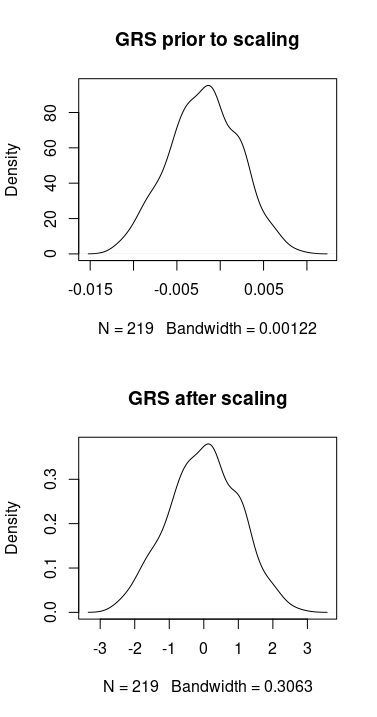

GRS distribution before and after scaling

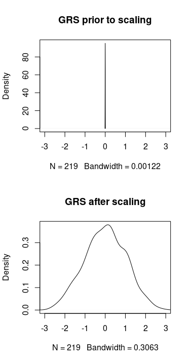

GRS distribution before and after scaling, on the same x-axis

## Model with genotype PCs only

```r
fit1 <- glm(PD ~ GRS_scaled + sex + age + geno_V3 + geno_V4 + geno_V5, data = meta, family = "binomial")
summary(fit1) #GRS: p = 0.0023 (unchanged from unscaled version)
fit1_null <- glm(PD ~ sex + age + geno_V3 + geno_V4 + geno_V5, data = meta, family = "binomial")
summary(fit1_null) #nothing sig
(cross_r2 <- nagelkerke(fit1, null = fit1_null))
#                             Pseudo.R.squared
#McFadden                            0.0366160
#Cox and Snell (ML)                  0.0446199
#Nagelkerke (Cragg and Uhler)        0.0626223

#these stats are identical to the model with unscaled GRS

# observed R2 from linear model (WC calculation)
#lin1 <- lm(PD ~ GRS_scaled + sex + age + geno_V3 + geno_V4 + geno_V5, data = meta)
#lin2 <- lm(PD ~ sex + age + geno_V3 + geno_V4 + geno_V5, data = meta)
#R2 <- (deviance(lin2) - deviance(lin1)) / deviance(lin2)

#liability scale heritability calculation from WC (ascertainment-adjusted)
#pd_h2 <- function(R2O, case_prop, prevalence = 0.22) {
#  K <- prevalence
#  P <- case_prop
#  thd <- -1 * qnorm(K, 0, 1)
#  zv <- dnorm(thd) # z (normal density)
#  mv <- zv / K # mean liability for case
#  theta <- mv * (P - K) / (1 - K) * (mv * (P - K) / (1 - K) - thd) # θ in equation
#  cv <- K * (1 - K) / zv^2 * K * (1 - K) / (P * (1 - P)) # C in
#  return(R2O * cv / (1 + R2O * theta * cv))
#}

#liability scale heritability calculation, mirroring Lee et al. approach
lee_h2 <- function(R2O, case_prop, prevalence) {
  K <- prevalence
  P <- case_prop
  thd <- qnorm(1 - K) # Threshold
  z <- dnorm(thd) # Height of the normal density at the threshold
  h2_liab <- R2O * (K * (1 - K) / z^2) * (K * (1 - K) / (P * (1 - P)))
  return(h2_liab)
}

R2 <- cross_r2$Pseudo.R.squared.for.model.vs.null[3]
summary(as.factor(meta$PD))
#  0   1
#148  71
h2 <- lee_h2(R2, 71/219, 5/1000)
R2 #0.0626223
h2 #0.03383469
```

## Sex-stratified models

```r
fit1_male <- glm(PD ~ GRS_scaled + age + geno_V3 + geno_V4 + geno_V5, data = meta[meta$sex == "M", ], family = "binomial")
summary(fit1_male) #GRS scaled: p = 0.04 (did not come up previously)
fit1_male_null <- glm(PD ~ age + geno_V3 + geno_V4 + geno_V5, data = meta[meta$sex == "M", ], family = "binomial")
summary(fit1_male_null) #nothing significant
(male_r2 <- nagelkerke(fit1_male, null = fit1_male_null))
#                             Pseudo.R.squared
#McFadden                            0.0299343
#Cox and Snell (ML)                  0.0362865
#Nagelkerke (Cragg and Uhler)        0.0511733

# liability R2 for updated male model
R2 <- male_r2$Pseudo.R.squared.for.model.vs.null[3]
summary(as.factor(meta[meta$sex=="M","PD"]))
# 0  1
#81 38
h2 <- lee_h2(R2, 38/119, 5/1000)
R2 #0.0511733
h2 #0.02786979

fit1_female <- glm(PD ~ GRS_scaled + age + geno_V3 + geno_V4 + geno_V5, data = meta[meta$sex == "F", ], family = "binomial")
summary(fit1_female) #GRS p = 0.01 (previously p = 0.02)
fit1_female_null <- glm(PD ~ age + geno_V3 + geno_V4 + geno_V5, data = meta[meta$sex == "F", ], family = "binomial")
summary(fit1_female_null) #nothing sig
(female_r2 <- nagelkerke(fit1_female, null = fit1_female_null))
#                             Pseudo.R.squared
#McFadden                            0.0543914
#Cox and Snell (ML)                  0.0657220
#Nagelkerke (Cragg and Uhler)        0.0921182

# liability R2 for updated female model
R2 <- female_r2$Pseudo.R.squared.for.model.vs.null[3]
summary(as.factor(meta[meta$sex=="F","PD"]))
# 0  1
#67 33
h2 <- lee_h2(R2, 33/100, 5/1000)
R2 #0.0921182
h2 #0.04931985
```

### Plotting cross-sex and sex-stratified GRS models

```r
r2_labels <- c(0.0626,0.0512,0.0921)
names(r2_labels) <- c("Cross-sex","Male","Female")
h2_labels <- c(0.0338,0.0279,0.0493)
names(h2_labels) <- c("Cross-sex","Male","Female")

to_plot <- meta %>%
  mutate(
    PD = ifelse(PD, "CASE", "CONTROL"),
    Sex = ifelse(sex == "M", "Male", "Female")
  ) %>%  mutate(Sex = factor(Sex, levels = c("Cross-sex", "Male", "Female")))
cross_data <- meta %>% mutate(PD = ifelse(PD, "CASE", "CONTROL"))
cross_data$Sex <- "Cross-sex"
to_plot <- rbind(cross_data, to_plot)
library(DescTools)
to_plot$Sex <- reorder.factor(to_plot$Sex, new.order=c("Cross-sex","Male","Female"))

png("~/PD_GRS/prs_plots_by_PD_sex_17May2025.png", width=600, height=500)
ggboxplot(
  to_plot,
  x = "PD",
  y = "GRS_scaled",
  color = "Sex",
  add = "jitter"
) +
  facet_grid(~Sex, labeller = label_bquote(cols = .(as.character(Sex)) ~ R^2 ~ ": " ~ .(r2_labels[Sex]) ~ ";" ~ h^2 ~ ": " ~ .(h2_labels[Sex]))) +
  labs(y = "Genetic Risk Score (Scaled)", x = "Parkinson's Diagnosis") +
  scale_color_manual(values = c("gray", "lightblue", "pink"))
dev.off()

png("~/PD_GRS/prs_plots_by_sex_17May2025.png", width=300, height=500)
ggboxplot(
  to_plot,
  x = "Sex",
  y = "GRS_scaled",
  color = "Sex",
  add = "jitter"
) +
  stat_compare_means() +

  labs(y = "Genetic Risk Score (Scaled)") +
  scale_color_manual(values = c("Male" = "light blue", "Female" = "pink"))
dev.off()
```

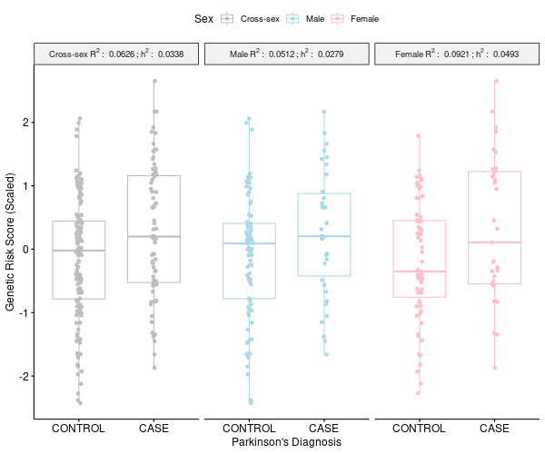

GRS by PD status and sex

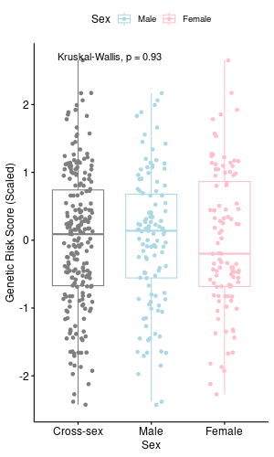

PRS by sex (cases and controls combined)

## Additional sensitivity tests

Interactions with PRS x sex, PRS x smoking, and PRS x pesticides will be explored here to see if they better explain PD status.

```r
fit2 <- glm(PD ~ GRS_scaled * sex + age + geno_V3 + geno_V4 + geno_V5, data = meta, family = "binomial")
summary(fit2) #PRS p = 0.02, interaction p = 0.69
fit3 <- glm(PD ~ GRS_scaled * smoking + sex + age + geno_V3 + geno_V4 + geno_V5, data = meta, family = "binomial")
summary(fit3) # PRS p = 0.36, smoking p = 0.02, interaction p = 0.83
fit4 <- glm(PD ~ GRS_scaled * pesticides + sex + age + geno_V3 + geno_V4 + geno_V5, data = meta, family = "binomial")
summary(fit4) #PRS p = 0.05, pest p = 0.29, geno V4 p = 0.04, interaction p = 0.91

fit_null <- glm(PD ~ GRS_scaled, data = meta, family = "binomial")
summary(fit_null) #p = 0.0039
```